# Error Checking

Naomi Tague

January, 2021

# Review

- We are using functions as a way to design modular programs (that might involve many functions that are linked together)
- We always start with clearly defininng our goal for the whole program and each piece (and diagramming this if needed for programs made of multiple functions)
- Always write your function in a text editor and then copy into R
- By convention we name files with functions in them by the name of the function.R e.g. **power_gen_orig.R**
- you can have R read a text file by source(“power_gen.R”) - make sure you are in the right working directory
- keep organized by keeping all functions in a subdirectory called *R*
- Eventually we will want our function to be part of a package (a library of many functions) - to create a package you must use this convention (name.R) place all function in a directory called “R”

```r
source("R/power_gen_orig.R")
```

```
## Error in file(filename, "r", encoding = encoding): cannot open the connection
```

# Multiple inputs

For a function with more than one input R can handle multiple values

**IF**

- all (multiple) inputs have the same number of values
- all other inputs or parameters have a single value

For other cases, additional instructions would need to be included in the function to help R understand what to do

Consider our reservoir function ( **R/power_gen_orig.R**)

```r
#source("R/power_gen_orig.R")

power_gen_orig= function(height, flow, rho=1000, g=9.8, Keff=0.8) {

  # calculate power
  result = rho * height * flow * g * Keff
  return(result)
}

# single
power_gen_orig(height=2, flow=2)
```

```
## [1] 31360
```

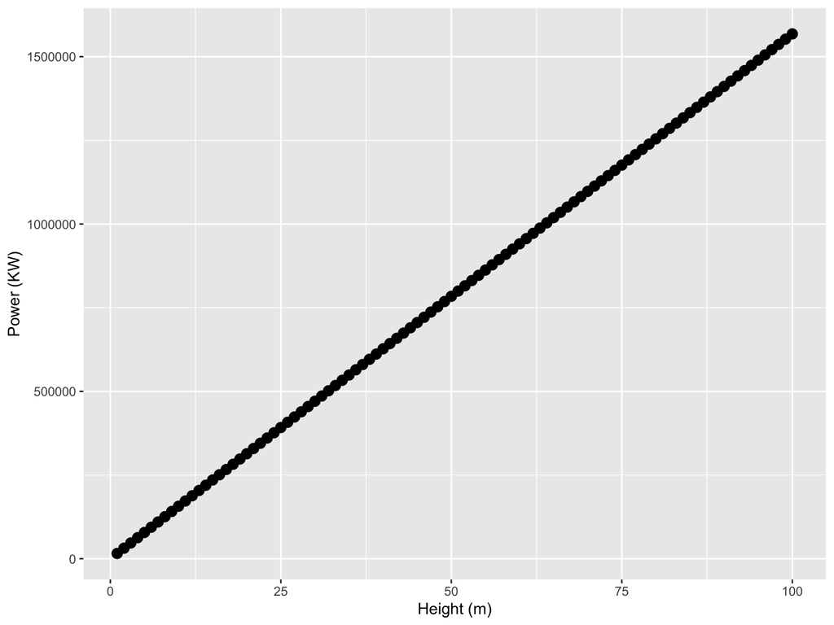

```r
# multiple heights
# generate a structure to store results
# consider all heights from 1 to 100

resv_results = data.frame(height=seq(from=1, to=100))

# compute power generated for EACH height
resv_results$power = power_gen_orig(resv_results$height, flow=2)

# plot
ggplot(resv_results, aes(height, power))+geom_point(size=3)+labs(y="Power (KW)", x="Height (m)")
```

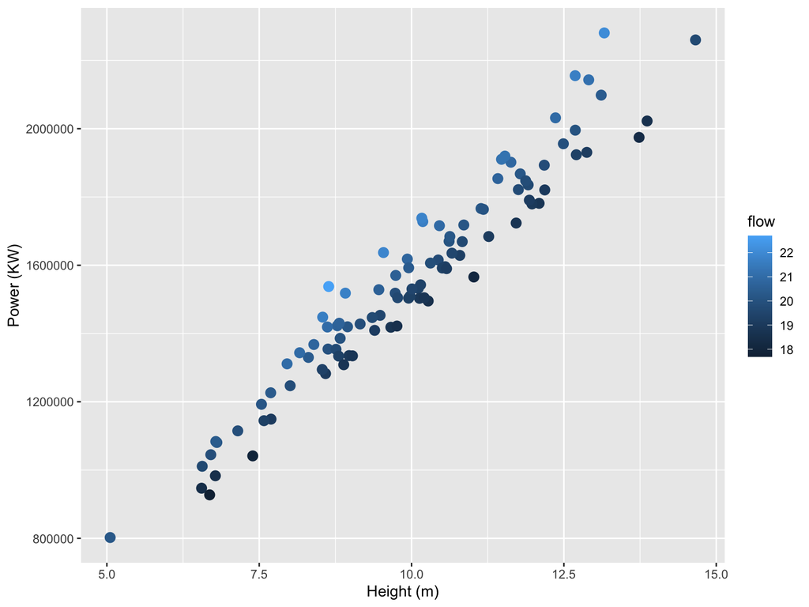

```r
# random combinations of height and flow
# use rnorm to sample from a normal distribution
resv_results$height = rnorm(mean=10, sd=2, n=100)
resv_results$flow = rnorm(mean=20, sd=1, n=100)
# compute power generated for EACH height
resv_results$power = power_gen_orig(resv_results$height, flow=resv_results$flow)

# plot
ggplot(resv_results, aes(height, power, col=flow))+geom_point(size=3)+labs(y="Power (KW)", x="Height (m)")
```

```r
# Unequal lengths - this will "work" but inputs get recycled unclear what is happening
# NOT recommended

eheight = seq(from=1, to=50)
eflow = runif(min=0.1, max=2, n=100)
resv_result = power_gen_orig(eheight, eflow)

# better
eheight = seq(from=1, to=50)
eflow = runif(min=0.1, max=2, n=50)
resv_result = power_gen_orig(eheight, eflow)

# another example of the problem of unequal length inputs
power_gen_orig(eheight, eflow, g=c(9,10,11))
```

```
##  [1]   5053.716  31027.770  14354.359  46536.020  33553.745  72140.994
##  [7]  85731.392  15939.394  23927.616  12600.420  87980.961 113501.722
## [13]  32826.032 113685.472 207046.315 227340.188 130110.652 174193.345
## [19]  35267.690  51801.240 321142.123 220263.835 267089.541  35239.532
## [25] 292153.326 384307.455 401991.264 119257.176 454631.795 278602.305
## [31] 347690.772  50584.890 365668.979 102897.964 486572.970 144183.720
## [37] 390994.133 228602.739 221614.376 282975.082  67733.889 664314.658
## [43] 390475.747 430988.201 788848.409 509266.239 579396.275 197407.055
## [49] 210625.166 421494.703
```

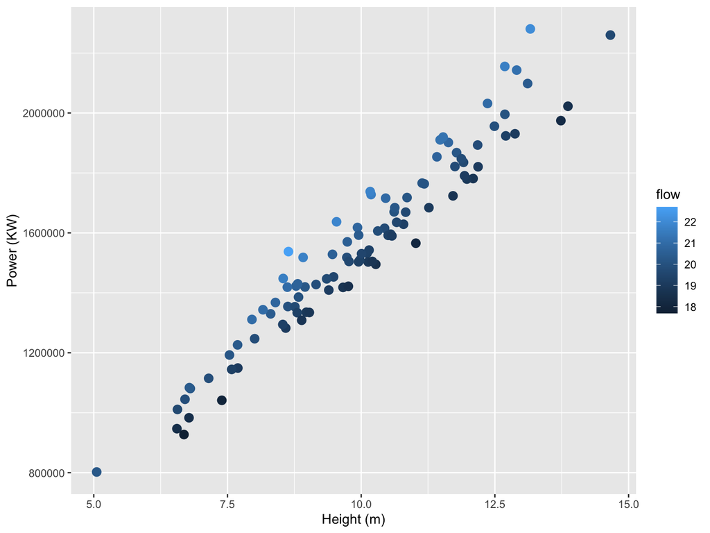

```r
#better
g = runif(min=8, max=10, n=50)
resv_result = power_gen_orig(eheight, eflow, g)
ggplot(resv_results, aes(height, power, col=flow))+geom_point(size=3)+labs(y="Power (KW)", x="Height (m)")
```

# Error Checking

What will your function do if user gives you garbage data, imagine that you have a function that computes microbial growth rates with temperature

- Two options

1. error-checking (nice)

if temperature < -100 or > 100

- set results to NA
- or exit function with a warming

2. assume user reads the contract :) return unrealistic values

if input -999.0, will still try to output growth rate

Error-checking is helpful if you are going to build a model made up of many functions- why?

# How to add error checking

Consider this example (I’m going to put the function definition inline for now so you can easily see it - later we will save to our R subdirectory for reuse)

```r
power_gen = function(height, flow, rho=1000, g=9.8, Keff=0.8) {
  # make sure inputs are positive and if not set as NA so result will be NA
   if (height < 0) height=NA

 # an alterative is to exit the function prematurely
  if (flow < 0) return("Flow cannot be less than 0")
  #    return("Height cannot be less than 0")

  # calculate power
    result = rho * height * flow * g * Keff
  return(result)
}

power_gen(2,3)
```

```
## [1] 47040
```

```r
power_gen(-2,3)
```

```
## [1] NA
```

```r
power_gen(2,-3)
```

```
## [1] "Flow cannot be less than 0"
```

While this works for a case with one height and one flow It will have problems if we use multiple heights - (a later topic)

A better implementation if you think the function might be run for multiple heights - YES you can do that

```r
power_gen = function(height, flow, rho=1000, g=9.8, Keff=0.8) {
  # make sure inputs are positive and if not set as NA so result will be NA
   height = ifelse( (height < 0), NA, height)

 # an alterative is to exit the function prematurely
  flow = ifelse((flow < 0), return("flow must be greater than zero"), flow)

  #    return("Height cannot be less than 0")

  # calculate power
    result = rho * height * flow * g * Keff
  return(result)
}

power_gen(2,3)
```

```
## [1] 47040
```

```r
power_gen(-2,3)
```

```
## [1] NA
```

```r
power_gen(2,-3)
```

```
## [1] "flow must be greater than zero"
```

```r
# note that this works (calculates power for each height)
power_gen(height=c(1,4,5), flow=2)
```

```
## [1] 15680 62720 78400
```

```r
# and this works (calculates power for each flow rate)
power_gen(height=4, flow=c(2,4,5))
```

```
## [1]  62720 125440 156800
```

```r
# and this calculates power for each combination of flow and height
power_gen(height=c(4,5,6), flow=c(2,4,6))
```

```
## [1]  62720 156800 282240
```

```r
# but this doesn't work - why?
power_gen(height=c(4,5,6, 8, 9, 20), flow=c(2,4,6))
```

```
## [1]  62720 156800 282240 125440 282240 940800
```

```r
# we could add error checking to test for this

power_gen = function(height, flow, rho=1000, g=9.8, Keff=0.8) {

  # make sure we have same number of flow and height's so we can match them
  if (length(height) != length(flow)) return(" number of heights is different from number of flows")
  # make sure inputs are positive and if not set as NA so result will be NA
   height = ifelse( (height < 0), NA, height)

 # an alterative is to exit the function prematurely
  flow = ifelse((flow < 0), return("flow must be greater than zero"), flow)

  #    return("Height cannot be less than 0")

  # calculate power
    result = rho * height * flow * g * Keff
  return(result)
}

power_gen(height=c(4,5,6, 8, 9, 20), flow=c(2,4,6))
```

```
## [1] " number of heights is different from number of flows"
```

```r
power_gen(height=c(4,5,6), flow=c(2,4,6))
```

```
## [1]  62720 156800 282240
```

See **power_gen.R** for file with error checking

Error checking is good practice - and combinded with good documentation - makes programming much much easier!